# **NOTE:** Use File > Save a copy in Drive to make a copy before doing anything else

# Project 6: Data Exploration and Visualization

### Overview

In this project, you will apply data exploration and visualization techniques to a real-world dataset of your choice. You'll practice using pandas for data analysis and create meaningful visualizations to gain insights from your data. This project builds on your Python programming skills while introducing you to the exciting world of data science.

In [Lab6](https://colab.research.google.com/drive/1WxHaCZlN8d0kVgTCBmbMWmF29TM4pDJs?usp=sharing), you explore the titanic dataset and you should use it as a sample and pick a dataset of your interest to do a similar data exploration and visualization.

### Project Objectives

- Find and select a dataset from a real-world data source
- Formulate a clear inquiry question based on your chosen dataset
- Perform exploratory data analysis using pandas functions
- Create at least two meaningful data visualizations
- Analyze your findings and answer your inquiry question
- Reflect on the insights gained through data exploration

### Data Sources

You can choose from various online data sources such as:

- [Kaggle](https://www.kaggle.com/datasets) - Wide variety of datasets
- [data.gov](https://www.data.gov/) - U.S. government data
- [Our World in Data](https://ourworldindata.org/) - Global development data
- [GitHub](https://github.com/datasets) - Curated datasets
- [Google Dataset Search](https://datasetsearch.research.google.com/) - Search for datasets
- Or any other reliable data source you find interesting

## Part 1: Dataset Selection and Initial Exploration

#### TODO Tasks:

1. Select Your Dataset: Choose a dataset that interests you. Make sure it has at least 100 rows and multiple columns with different data types (e.g., numerical, categorical, dates).

Please create either text or code cells in between the TODO tasks to do the work.

2. Import Libraries: Import the necessary libraries (pandas, matplotlib, seaborn) at the beginning of your notebook by creating code cells below this text cell.
3. Load Your Data: Load your chosen dataset using pandas and save it to a pandas dataframe. Please create a code cell below this text cell to do it.
4. Data Summary: Use the following functions to do inital exploration your dataset:
- info() - Display information about the dataset structure
- describe() - Show statistical summary of numerical columns
- head() - Display the first 5 rows (df.head())
- shape - Show the dimensions of the dataset (e.g. df.shape)
- columns - Get the column names (e.g. df.columns)

You may use 5 code cells below this text cell to accomplish it.

5. Inquiry Question: Write a clear, specific question that you want to answer using your dataset by creating a text cell below and **write the question in bold please.**

For example:

- "How has the average temperature changed in major cities over the past decade?"
- "What factors are most strongly correlated with housing prices?"
- "Is there a relationship between education level and income?"

```python
import pandas as pd
import matplotlib.pyplot as plt
import seaborn as sns
```

```python
from google.colab import drive
drive.mount('/content/drive')
df = pd.read_csv('/content/Average_Home_Heating_Oil_Prices_by_Region__Beginning_1997.csv')
```

```python
df.info()
```

```
<class 'pandas.core.frame.DataFrame'>
RangeIndex: 1057 entries, 0 to 1056
Data columns (total 10 columns):
 #   Column                              Non-Null Count  Dtype
---  ------                              --------------  -----
 0   Date                                1057 non-null   object
 1   New York Statewide Average ($/gal)  1057 non-null   float64
 2   Long Island Average ($/gal)         1057 non-null   float64
 3   New York City Average ($/gal)       1057 non-null   float64
 4   Lower Hudson Average ($/gal)        1057 non-null   float64
 5   Upper Hudson Average ($/gal)        1031 non-null   float64
 6   Capital District Average ($/gal)    1057 non-null   float64
 7   North Country Average ($/gal)       1057 non-null   float64
 8   Central New York Average ($/gal)    1057 non-null   float64
 9   Western New York Average ($/gal)    1057 non-null   float64
dtypes: float64(9), object(1)
memory usage: 82.7+ KB
```

```python
df.describe()
```

|  | New York Statewide Average ($/gal) | Long Island Average ($/gal) | New York City Average ($/gal) | Lower Hudson Average ($/gal) | Upper Hudson Average ($/gal) | Capital District Average ($/gal) | North Country Average ($/gal) | Central New York Average ($/gal) | Western New York Average ($/gal) |
| --- | --- | --- | --- | --- | --- | --- | --- | --- | --- |
| count | 1057.000000 | 1057.000000 | 1057.000000 | 1057.000000 | 1031.000000 | 1057.00000 | 1057.000000 | 1057.000000 | 1057.000000 |
| mean | 2.972015 | 3.101570 | 3.103349 | 3.027597 | 2.953686 | 2.82264 | 2.884749 | 2.831230 | 2.969830 |
| std | 1.075765 | 1.051544 | 1.070446 | 1.085213 | 1.049799 | 1.04782 | 1.070336 | 1.061152 | 1.146803 |
| min | 0.880000 | 1.090000 | 1.070000 | 0.950000 | 0.750000 | 0.80000 | 0.770000 | 0.770000 | 0.740000 |
| 25% | 2.350000 | 2.530000 | 2.500000 | 2.340000 | 2.325000 | 2.19000 | 2.300000 | 2.140000 | 2.310000 |
| 50% | 3.030000 | 3.130000 | 3.160000 | 3.040000 | 2.970000 | 2.86000 | 2.990000 | 2.850000 | 3.050000 |
| 75% | 3.830000 | 3.950000 | 4.000000 | 3.880000 | 3.750000 | 3.66000 | 3.660000 | 3.700000 | 3.790000 |
| max | 6.300000 | 6.460000 | 6.320000 | 6.510000 | 6.330000 | 6.20000 | 6.130000 | 5.910000 | 6.230000 |

```python
df.head()
```

|  | Date | New York Statewide Average ($/gal) | Long Island Average ($/gal) | New York City Average ($/gal) | Lower Hudson Average ($/gal) | Upper Hudson Average ($/gal) | Capital District Average ($/gal) | North Country Average ($/gal) | Central New York Average ($/gal) | Western New York Average ($/gal) |
| --- | --- | --- | --- | --- | --- | --- | --- | --- | --- | --- |
| 0 | 09/08/1997 | 1.00 | 1.20 | 1.19 | 1.00 | NaN | 0.94 | 0.87 | 0.89 | 0.90 |
| 1 | 09/22/1997 | 1.00 | 1.19 | 1.19 | 1.00 | NaN | 0.93 | 0.87 | 0.89 | 0.90 |
| 2 | 10/06/1997 | 1.02 | 1.20 | 1.21 | 1.02 | NaN | 0.95 | 0.89 | 0.91 | 0.91 |
| 3 | 10/20/1997 | 1.02 | 1.21 | 1.21 | 1.03 | NaN | 0.96 | 0.90 | 0.91 | 0.92 |
| 4 | 11/03/1997 | 1.03 | 1.22 | 1.21 | 1.04 | NaN | 0.96 | 0.90 | 0.92 | 0.93 |

```python
df.shape
```

```
(1057, 10)
```

```python
df.columns
```

```
Index(['Date', 'New York Statewide Average ($/gal)',
       'Long Island Average ($/gal)', 'New York City Average ($/gal)',
       'Lower Hudson Average ($/gal)', 'Upper Hudson Average ($/gal)',
       'Capital District Average ($/gal)', 'North Country Average ($/gal)',
       'Central New York Average ($/gal)', 'Western New York Average ($/gal)'],
      dtype='object')
```

# Questions About Dataset

1. What is the trend of heating oil prices in homes across New York? Is there a major price up between the counties?
2. do the price flucutate the same as the economic market? Are they increase or decreasing over time?

## Part 2: Data Visualization and Analysis

#### TODO Tasks:

1. Data Cleaning (if necessary): Check for and handle any missing values, duplicates, or data quality issues.

**NOTE: This could be a daunting task even for seasoned data scientists. My suggestion is to use a dataset that is already clean if you can for the purpose of completing this assignment in a week.**

Examples:

- Checking for missing values: df.isnull().sum()
- Dropping rows with any missing values: df.dropna(inplace=True)
- Dropping columns with all missing values: df.dropna(axis=1, how='all', inplace=True)
- Removing duplicate row: df.drop_duplicates(inplace=True)
2. Create Visualizations: Create at least 2 different types of visualizations that help answer your research question. Choose from:
- Bar charts
- Line plots
- Scatter plots
- Histograms
- Box plots
- Heatmaps
- Any other appropriate visualization
3. Customize Your Plots: Make sure your visualizations are clear and informative by:
- Adding appropriate titles
- Labeling axes
- Using colors effectively
- Adding legends when necessary

Please create code cells below this to create your visualizations.

4. Analysis: Write 1-2 paragraphs discussing:
- Whether your research question can be answered with the available data
- What insights you discovered through your visualizations
- Any unexpected or interesting findings
- Limitations of your analysis
- Suggestions for further investigation

Please create a text cell below this cell to write your analysis.

```python
print("Missing values before cleaning:")
print(df.isnull().sum())

# Drop rows with any missing values
df.dropna(inplace=True)

print("\nMissing values after dropping rows:")
print(df.isnull().sum())

print("\nNew DataFrame shape after cleaning:", df.shape)
```

```
Missing values before cleaning:
Date                                   0
New York Statewide Average ($/gal)     0
Long Island Average ($/gal)            0
New York City Average ($/gal)          0
Lower Hudson Average ($/gal)           0
Upper Hudson Average ($/gal)          26
Capital District Average ($/gal)       0
North Country Average ($/gal)          0
Central New York Average ($/gal)       0
Western New York Average ($/gal)       0
dtype: int64

Missing values after dropping rows:
Date                                  0
New York Statewide Average ($/gal)    0
Long Island Average ($/gal)           0
New York City Average ($/gal)         0
Lower Hudson Average ($/gal)          0
Upper Hudson Average ($/gal)          0
Capital District Average ($/gal)      0
North Country Average ($/gal)         0
Central New York Average ($/gal)      0
Western New York Average ($/gal)      0
dtype: int64

New DataFrame shape after cleaning: (1031, 10)
```

# Visualization 1

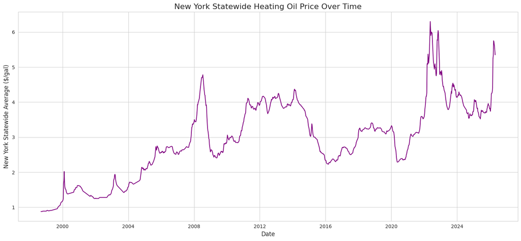

```python
# Ensure 'Date' column is in datetime format and sort the DataFrame
df['Date'] = pd.to_datetime(df['Date'])
df = df.sort_values(by='Date')

# Set the aesthetic style of the plots
sns.set_style("whitegrid")

# --- Visualization 1: Line Plot for Statewide Average Price over Time ---
plt.figure(figsize=(15, 7))
sns.lineplot(x='Date', y='New York Statewide Average ($/gal)', data=df, color='Purple')
plt.title('New York Statewide Heating Oil Price Over Time', fontsize=16)
plt.xlabel('Date', fontsize=12)
plt.ylabel('New York Statewide Average ($/gal)', fontsize=12)
plt.grid(True)
plt.tight_layout()
plt.show()
```